# Loan Data Exploration

## Preliminary Wrangling

This report details the exploration of a loan dataset with particular reference to the interest rate and other key variables of these loans for approximately 115,000 people

```python
# import all packages and set plots to be embedded inline
import numpy as np
import pandas as pd
import matplotlib.pyplot as plt
import seaborn as sb

%matplotlib inline
```

```python
# set np.random.seed to maintain consistency in random selections
np.random.seed(100)
```

```python
# load the dataset
loan_data = pd.read_csv('prosperLoanData.csv')
```

```python
# Assess the data visually
loan_data.head(10)
```

|  | ListingKey | ListingNumber | ListingCreationDate | CreditGrade | Term | LoanStatus | ClosedDate | BorrowerAPR | BorrowerRate | LenderYield | ... | LP_ServiceFees | LP_CollectionFees | LP_GrossPrincipalLoss | LP_NetPrincipalLoss | LP_NonPrincipalRecoverypayments | PercentFunded | Recommendations | InvestmentFromFriendsCount | InvestmentFromFriendsAmount | Investors |
| --- | --- | --- | --- | --- | --- | --- | --- | --- | --- | --- | --- | --- | --- | --- | --- | --- | --- | --- | --- | --- | --- |
| 0 | 1021339766868145413AB3B | 193129 | 26/08/2007 19:09 | C | 36 | Completed | 14/08/2009 00:00 | 0.16516 | 0.1580 | 0.1380 | ... | -133.18 | 0.0 | 0.0 | 0.0 | 0.0 | 1.0 | 0 | 0 | 0.0 | 258 |
| 1 | 10273602499503308B223C1 | 1209647 | 27/02/2014 08:28 | NaN | 36 | Current | NaN | 0.12016 | 0.0920 | 0.0820 | ... | 0.00 | 0.0 | 0.0 | 0.0 | 0.0 | 1.0 | 0 | 0 | 0.0 | 1 |
| 2 | 0EE9337825851032864889A | 81716 | 05/01/2007 15:00 | HR | 36 | Completed | 17/12/2009 00:00 | 0.28269 | 0.2750 | 0.2400 | ... | -24.20 | 0.0 | 0.0 | 0.0 | 0.0 | 1.0 | 0 | 0 | 0.0 | 41 |
| 3 | 0EF5356002482715299901A | 658116 | 22/10/2012 11:02 | NaN | 36 | Current | NaN | 0.12528 | 0.0974 | 0.0874 | ... | -108.01 | 0.0 | 0.0 | 0.0 | 0.0 | 1.0 | 0 | 0 | 0.0 | 158 |
| 4 | 0F023589499656230C5E3E2 | 909464 | 14/09/2013 18:38 | NaN | 36 | Current | NaN | 0.24614 | 0.2085 | 0.1985 | ... | -60.27 | 0.0 | 0.0 | 0.0 | 0.0 | 1.0 | 0 | 0 | 0.0 | 20 |
| 5 | 0F05359734824199381F61D | 1074836 | 14/12/2013 08:26 | NaN | 60 | Current | NaN | 0.15425 | 0.1314 | 0.1214 | ... | -25.33 | 0.0 | 0.0 | 0.0 | 0.0 | 1.0 | 0 | 0 | 0.0 | 1 |
| 6 | 0F0A3576754255009D63151 | 750899 | 12/04/2013 09:52 | NaN | 36 | Current | NaN | 0.31032 | 0.2712 | 0.2612 | ... | -22.95 | 0.0 | 0.0 | 0.0 | 0.0 | 1.0 | 0 | 0 | 0.0 | 1 |
| 7 | 0F1035772717087366F9EA7 | 768193 | 05/05/2013 06:49 | NaN | 36 | Current | NaN | 0.23939 | 0.2019 | 0.1919 | ... | -69.21 | 0.0 | 0.0 | 0.0 | 0.0 | 1.0 | 0 | 0 | 0.0 | 1 |
| 8 | 0F043596202561788EA13D5 | 1023355 | 02/12/2013 10:43 | NaN | 36 | Current | NaN | 0.07620 | 0.0629 | 0.0529 | ... | -16.77 | 0.0 | 0.0 | 0.0 | 0.0 | 1.0 | 0 | 0 | 0.0 | 1 |
| 9 | 0F043596202561788EA13D5 | 1023355 | 02/12/2013 10:43 | NaN | 36 | Current | NaN | 0.07620 | 0.0629 | 0.0529 | ... | -16.77 | 0.0 | 0.0 | 0.0 | 0.0 | 1.0 | 0 | 0 | 0.0 | 1 |

10 rows × 81 columns

```python
# check number of rows and columns in the dataset
loan_data.shape
```

```
(113937, 81)
```

```python
# assess the data programmatically
loan_data.info()
```

```
<class 'pandas.core.frame.DataFrame'>
RangeIndex: 113937 entries, 0 to 113936
Data columns (total 81 columns):
 #   Column                               Non-Null Count   Dtype
---  ------                               --------------   -----
 0   ListingKey                           113937 non-null  object
 1   ListingNumber                        113937 non-null  int64
 2   ListingCreationDate                  113937 non-null  object
 3   CreditGrade                          28953 non-null   object
 4   Term                                 113937 non-null  int64
 5   LoanStatus                           113937 non-null  object
 6   ClosedDate                           55089 non-null   object
 7   BorrowerAPR                          113912 non-null  float64
 8   BorrowerRate                         113937 non-null  float64
 9   LenderYield                          113937 non-null  float64
```

[output cut: 73 more lines]

```python
# create new data with columns to be used in the exploration
df = loan_data.iloc[:, [3,4,7,8,14,17,19,21,49,63,65]]
df.head()
```

|  | CreditGrade | Term | BorrowerAPR | BorrowerRate | ProsperRating (Alpha) | BorrowerState | EmploymentStatus | IsBorrowerHomeowner | StatedMonthlyIncome | LoanOriginalAmount | LoanOriginationQuarter |
| --- | --- | --- | --- | --- | --- | --- | --- | --- | --- | --- | --- |
| 0 | C | 36 | 0.16516 | 0.1580 | NaN | CO | Self-employed | True | 3083.333333 | 9425 | Q3 2007 |
| 1 | NaN | 36 | 0.12016 | 0.0920 | A | CO | Employed | False | 6125.000000 | 10000 | Q1 2014 |
| 2 | HR | 36 | 0.28269 | 0.2750 | NaN | GA | Not available | False | 2083.333333 | 3001 | Q1 2007 |
| 3 | NaN | 36 | 0.12528 | 0.0974 | A | GA | Employed | True | 2875.000000 | 10000 | Q4 2012 |
| 4 | NaN | 36 | 0.24614 | 0.2085 | D | MN | Employed | True | 9583.333333 | 15000 | Q3 2013 |

```python
# convert to categorical variable
df[['BorrowerState', 'EmploymentStatus', 'LoanOriginationQuarter']] = df[['BorrowerState', 'EmploymentStatus', 'LoanOriginationQuarter']].apply(pd.Categorical)
```

```python
# convert to ordered categorical varible
ordered_cat = {'CreditGrade': ['NC', 'HR', 'E', 'D', 'C', 'B', 'A', 'AA'],
              'ProsperRating (Alpha)': ['HR', 'E', 'D', 'C', 'B', 'A', 'AA']}

for col in ordered_cat:
    ordered_var = pd.api.types.CategoricalDtype(ordered = True,
                                               categories = ordered_cat[col])
    df[col] = df[col].astype(ordered_var)
```

```python
# rename all the columns in the dataset
df.rename(columns={'CreditGrade': 'credit_grade', 'Term': 'term', 'BorrowerAPR': 'borrower_apr', 'BorrowerRate': 'borrower_rate',
                  'ProsperRating (Alpha)': 'prosper_rating', 'BorrowerState': 'borrower_state', 'EmploymentStatus': 'employment_status',
                  'IsBorrowerHomeowner': 'is_borrower_homeowner', 'StatedMonthlyIncome': 'stated_monthly_income', 'LoanOriginalAmount':
                  'loan_original_amount', 'LoanOriginationQuarter': 'loan_origination_quarter'}, inplace=True)
```

```python
# Display the summary statistics of the dataset
df.describe()
```

|  | term | borrower_apr | borrower_rate | stated_monthly_income | loan_original_amount |
| --- | --- | --- | --- | --- | --- |
| count | 113937.000000 | 113912.000000 | 113937.000000 | 1.139370e+05 | 113937.00000 |
| mean | 40.830248 | 0.218828 | 0.192764 | 5.608026e+03 | 8337.01385 |
| std | 10.436212 | 0.080364 | 0.074818 | 7.478497e+03 | 6245.80058 |
| min | 12.000000 | 0.006530 | 0.000000 | 0.000000e+00 | 1000.00000 |
| 25% | 36.000000 | 0.156290 | 0.134000 | 3.200333e+03 | 4000.00000 |
| 50% | 36.000000 | 0.209760 | 0.184000 | 4.666667e+03 | 6500.00000 |
| 75% | 36.000000 | 0.283810 | 0.250000 | 6.825000e+03 | 12000.00000 |
| max | 60.000000 | 0.512290 | 0.497500 | 1.750003e+06 | 35000.00000 |

```python
# Confirm that datatypes of all columns is authentic
df.info()
```

```
<class 'pandas.core.frame.DataFrame'>
RangeIndex: 113937 entries, 0 to 113936
Data columns (total 11 columns):
 #   Column                    Non-Null Count   Dtype
---  ------                    --------------   -----
 0   credit_grade              28953 non-null   category
 1   term                      113937 non-null  int64
 2   borrower_apr              113912 non-null  float64
 3   borrower_rate             113937 non-null  float64
 4   prosper_rating            84853 non-null   category
 5   borrower_state            108422 non-null  category
 6   employment_status         111682 non-null  category
 7   is_borrower_homeowner     113937 non-null  bool
 8   stated_monthly_income     113937 non-null  float64
 9   loan_original_amount      113937 non-null  int64
 10  loan_origination_quarter  113937 non-null  category
dtypes: bool(1), category(5), float64(3), int64(2)
memory usage: 5.0 MB
```

```python
# Confirm if columns have been renamed accordingly
df.columns
```

```
Index(['credit_grade', 'term', 'borrower_apr', 'borrower_rate',
       'prosper_rating', 'borrower_state', 'employment_status',
       'is_borrower_homeowner', 'stated_monthly_income',
       'loan_original_amount', 'loan_origination_quarter'],
      dtype='object')
```

### What is the structure of your dataset?

The main dataset contains 113,937 rows and 81 columns. With regards to the datatype, a huge percentage of the columns in the dataset are either integer or float in nature.

However, with the new dataset (df) created, a greater percentage of the datatypes are categorical in nature. For example,

- credit_grade
- prosper_rating
- borrower_state
- employment_status
- loan_origination_quarter

### What is/are the main feature(s) of interest in your dataset?

The feature that have undoubtedly pique my interest is the borrower_rate variable. I am interested to know the relationship between these selected variables and the borrower_rate

### What features in the dataset do you think will help support your investigation into your feature(s) of interest?

I envisaged that prosper_rating as well as credit_grade would influence the borrower_rate: the higher the prosper_rating or credit_grade, the lower the interest rate. Also, the term (tenor) of the loan would influence the borrower_rate: the longer the tenor, the higher the interest rate.

## Univariate Exploration

I would commence by examining the main variable of interest (borrower_rate)

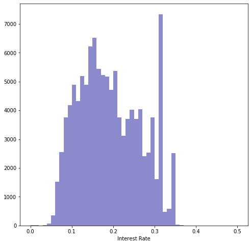

```python
# commence with a standard-scaled plot
plt.figure(figsize=[8, 8])

width = df['borrower_rate'].max()
bins = np.arange(0, (width)+0.01, 0.01)
colors = sb.light_palette('navy')[2]
plt.hist(data=df, x='borrower_rate', bins=bins, color=colors)
plt.xlabel('Interest Rate')
```

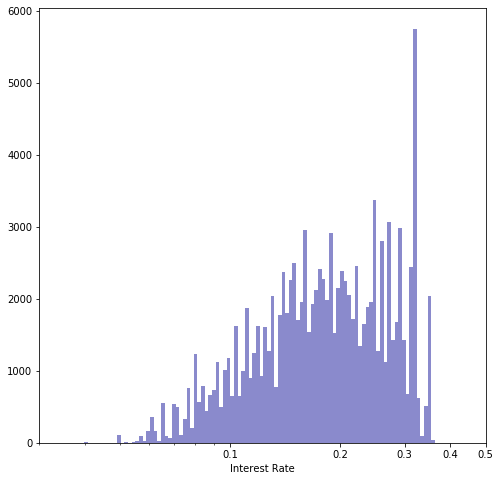

```python
# apply log scale to have an indepth view of the distribution
plt.figure(figsize=[8, 8])

width = df['borrower_rate'].max()
bins = 10 ** np.arange(-4, np.log10(width)+0.01, 0.01)
colors = sb.light_palette('navy')[2]
plt.hist(data=df, x='borrower_rate', bins=bins, color=colors)
plt.xscale('log')
ticks=[0.1,0.2,0.3,0.4,0.5]
plt.xticks(ticks, ticks)
plt.xlabel('Interest Rate')
plt.xlim(0.03, 0.5);
```

While reviewing the standard-scaled plot, there are so many points above 3,500 counts and the plot looks like a normal distribution. But when plotted on a log scale, most points were not up to 3,500 counts and the plot is skewed to the left.

The upcoming plot is the dependent variable of interest: prosper_rating & credit_grade

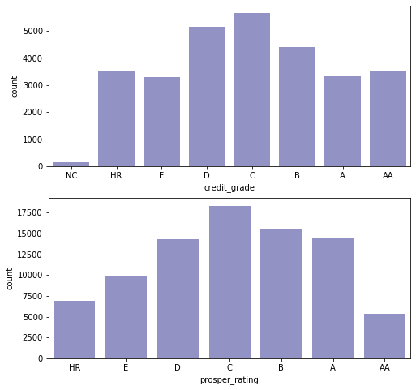

```python
# plot credit_grade & prosper_rating
fig, ax = plt.subplots(nrows=2, figsize=[8,8])

colour = sb.light_palette('navy')[2]
sb.countplot(data=df, x='credit_grade', color=colour, ax=ax[0])
sb.countplot(data=df, x='prosper_rating', color=colour, ax=ax[1])

plt.show()
```

For both credit_grade & prosper_rating variables, the rating, C, has the highest counts. Although AA rating has the least count in prosper_rating, it is not the least in credit_grade.

From both plots, it can be seen that individuals rarely get an NC rating. From the plot, NC count for credit_grade is next to nothing while NC count for prosper_rating is zero.

Next is the third predictor variable of interest: term

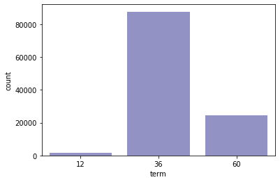

```python
# Execute barplot for the different loan tenors
colour = sb.light_palette('navy')[2]

sb.countplot(data=df, x='term', color=colour)
```

From the barplot above, it can be seen that the bulk of the loan request had a tenor of 36 months with over 80000 counts.

The next variable on my list is stated_monthly_income

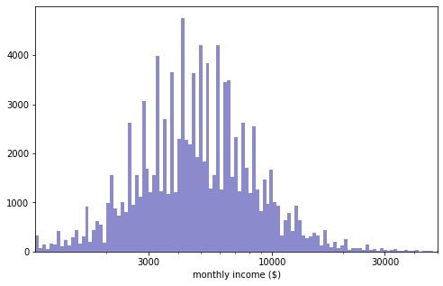

```python
# plot histogram for stated_monthly_income
width = df['stated_monthly_income'].max()
bins = 10 ** np.arange(0, np.log10(width)+0.015, 0.015)
colors = sb.light_palette('navy')[2]

plt.figure(figsize=[8, 5])
plt.hist(data=df, x='stated_monthly_income', bins=bins, color=colors)
plt.xscale('log')
ticks=[0, 3000, 10000, 30000, 100000]
plt.xticks(ticks, ticks)
plt.xlabel('monthly income ($)')
plt.xlim((1000, 50000));
```

From the monthly income log scale plotted above, it is evident that the plot is a normal distribution. Also, majority of individuals who requested for a loan earned 4k-5k monthly.

According to Investopedia, any individual who earns below $15,000 monthly (approx.) is considered a low income earner. This shows that most of the individuals who request for loans are low income earners.

The next variable on my list is the borrower_state

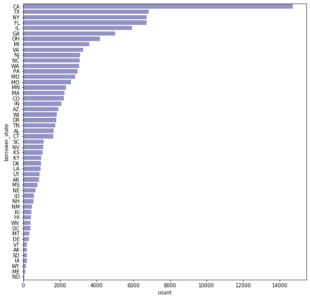

```python
# barplot for the borrower_state
colour = sb.light_palette('navy')[2]

plt.figure(figsize=[10,10])
bars = df.borrower_state.value_counts().index
sb.countplot(data=df, y='borrower_state', color=colour, order=bars)
```

From the barplot above, the state with the highest of borrowers is California while the state with the least amount of borrowers is North Dakota.

Next variable to investigate is the employment_status

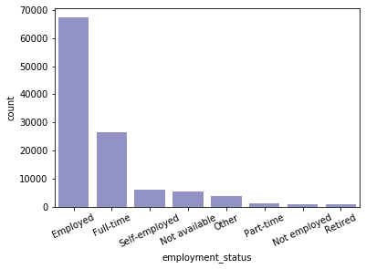

```python
# plot the counts for the employment status
colour = sb.light_palette('navy')[2]

bars = df.employment_status.value_counts().index
sb.countplot(data=df, x='employment_status', color=colour, order=bars)
plt.xticks(rotation=25)
```

A large amount of those offered loans are employed while the retired and unemployed fill the ranks of those with the least amount of loan offered.

Let's move onto is_borrower_homeowner

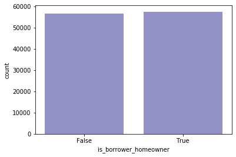

```python
# lets see the proportion of homeowners among the loanees
colour = sb.light_palette('navy')[2]

sb.countplot(data=df, x='is_borrower_homeowner', color=colour)
```

There is no substantial differences between loanees who own a house and those who don't own a house

The final univariate plot for consideration is the loan_origination_quarter

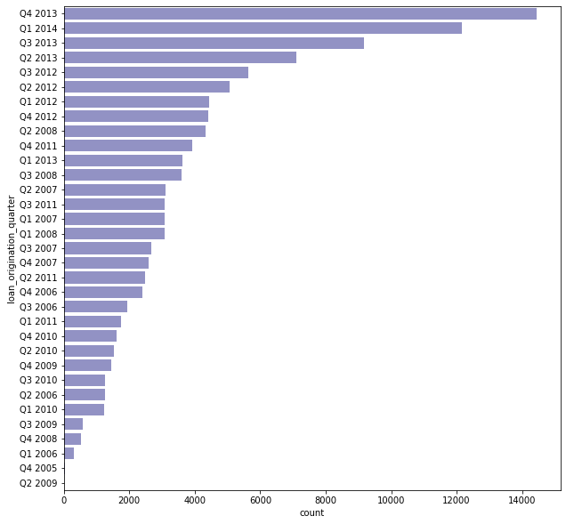

```python
# plot bar graph for loan_origination_quarter
colour = sb.light_palette('navy')[2]

plt.figure(figsize=[10,10])
bars = df.loan_origination_quarter.value_counts().index
sb.countplot(data=df, y='loan_origination_quarter', color=colour, order=bars)
```

Not arranged chronologically, the top 4 quarters with the highest amount of loanees are Q2 2013, Q3 2013, Q4 2013 and Q1 2014.

### Discuss the distribution(s) of your variable(s) of interest. Were there any unusual points? Did you need to perform any transformations?

On plotting the borrower_rate variable, it was discovered that it took a lot a large range of values. Hence, I decided to perform a log transform on the variable. Using this precedence, I also decided to perform a log transform on the stated_monthly_income variable.

### Of the features you investigated, were there any unusual distributions? Did you perform any operations on the data to tidy, adjust, or change the form of the data? If so, why did you do this?

None of the variables warranted me to perform any major operations on the data.

## Bivariate Exploration

In this section, I want to commence my exploration by looking at the relationship of 4 variables (credit_grade, prosper_rating, is_borrower_homeowner and employment_status) with borrower_rate

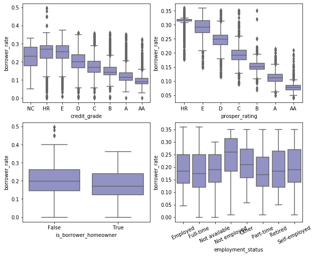

```python
# subplots of key variables against borrower_rate
plt.figure(figsize = [10,8])
colour = sb.light_palette('navy')[2]


plt.subplot(2,2,1)
sb.boxplot(data=df, x='credit_grade', y='borrower_rate', color=colour)

plt.subplot(2,2,2)
sb.boxplot(data=df, x='prosper_rating', y='borrower_rate', color=colour)

plt.subplot(2,2,3)
sb.boxplot(data=df, x='is_borrower_homeowner', y='borrower_rate', color=colour)

plt.subplot(2,2,4)
sb.boxplot(data=df, x='employment_status', y='borrower_rate', color=colour)
plt.xticks(rotation=25)
```

As seen for both credit_grade & prosper_rating, as the credit grade/prosper rating decreases, the borrower_rate increases. the rate of increase in prosper_rating is steeper and more consistent than that of credit_grade. It is also worthy to note that the NC rating for credit_grade has a lower median borrower_rate than E and HR rating.

Furthermore, for loanees who don't own a house, the median borrower_rate is higher than that of borrowers who own a house.

The employment_status subplot shows that the median borrower_rate for those who are unemployed is greater than in other employment status types.

In the upcoming plot, I would like to look at the relationship between the term (tenor) and borrower_rate

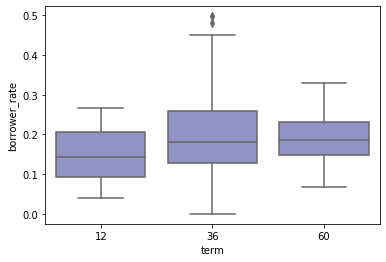

```python
# plot the relationship between term & borrower_rate using a boxplot
colour = sb.light_palette('navy')[2]
sb.boxplot(data=df, x='term', y='borrower_rate', color=colour)
```

Ideally, loan duration of 12 months has the lowest median borrower_rate.

```
(500, 80000)
```

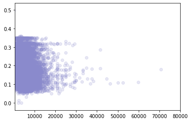

```python
# collect sample and plot relationship between stated_monthly_income & borrower_rate
colour = sb.light_palette('navy')[2]
samples = np.random.choice(df.shape[0], 10000, replace = False)
df_sample = df.loc[samples,:]

plt.scatter(data=df_sample, x='stated_monthly_income', y='borrower_rate', color=colour, alpha = 1/5)
plt.xlim(500, 80000)
```

```python
numerics = ['borrower_rate', 'stated_monthly_income', 'borrower_apr']
```

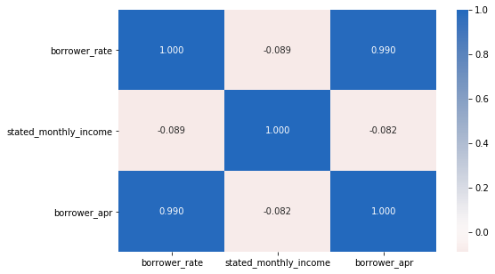

```python
# correlation plot
plt.figure(figsize = [8,5])
sb.heatmap(df[numerics].corr(), annot=True, fmt ='.3f', cmap='vlag_r', center=0)
plt.show()
```

From the scatterplot of stated_monthly_income against borrower_rate, I noticed that there wasn't a strong relationship between the two variables.

In light of the above, I went further to check the correlation coefficient to confirm that the relationship is actually poor. With a correlation coefficient of -0.089, the relationship is truly poor.

Next, I would look at the relationship between employment_status & borrower_rate

```
(0.03, 0.5)
```

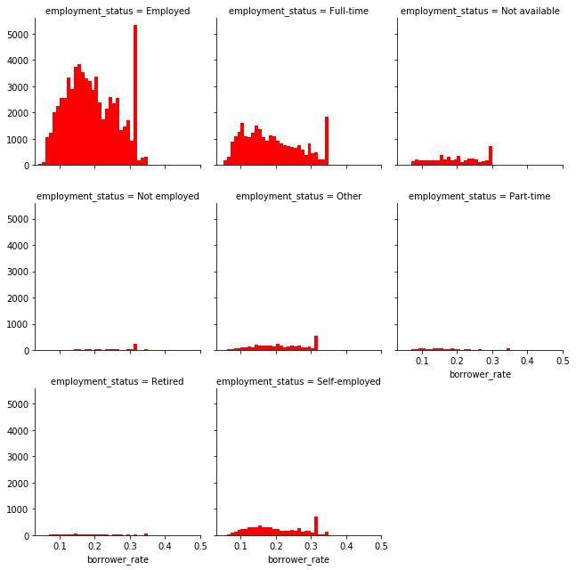

```python
# create faceted histograms of borrower rate againt
# the different employment status
width = df['borrower_rate'].max()
bins = np.arange(0, width+0.01, 0.01)
g = sb.FacetGrid(df, col='employment_status', col_wrap=3)
g = g.map(plt.hist, 'borrower_rate', bins=bins, color='r')
plt.xlim(0.03, 0.5)
```

In each of the faceted histograms (besides part-time & retired), it can be seen that there is always a spike in the interest rate count between 0.3 and 0.4.

Now, I want to look at the relationship between categorical variables of is_borrower_homeowner & prosper_rating

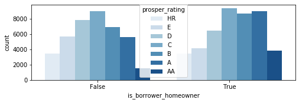

```python
# check the relationship between is_borrower_homeowner & prosper_rating
plt.figure(figsize=[8,8])

plt.subplot(3,1,1)
sb.countplot(data=df, x='is_borrower_homeowner', hue='prosper_rating', palette = 'Blues')
```

Borrowers who own a house had a higher prosper rating (AA, A, B, C) than borrowers who don't own a house.

### Talk about some of the relationships you observed in this part of the investigation. How did the feature(s) of interest vary with other features in the dataset?

As expected, credit_grade and prosper_rating greatly influenced the borrower_rate depicting a negative relationship. A minor positive correlation was seen between term and borrower_rate.

### Did you observe any interesting relationships between the other features (not the main feature(s) of interest)?

Also, higher credit and prosper ratings were associated with borrowers who own a house while lower credit scores were associated with borrowers who don't own a house.

Surprisingly, there was a very poor relationship between stated_monthly_income and borrower_rate. Although, from the scatterplot of stated_monthly_income against borrower_rate, it is evident that borrowers with higher monthly income have lower interest rate (borrower_rate) on their loans.

## Multivariate Exploration

Here, I want to further explore if there is a relationship between stated_monthly_income and borrower_rate

```
(0, 100000)
```

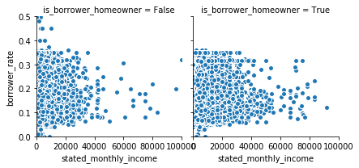

```python
# create faceted scatterplots
g = sb.FacetGrid(df, col='is_borrower_homeowner')
g.map(plt.scatter, 'stated_monthly_income', 'borrower_rate', edgecolor ='w')
plt.ylim(0, 0.5)
plt.xlim(0, 100000)
```

Here, it is displayed that some borrowers who don't own a home and with monthly income below $20,000 have a higher borrower_rate on their loans.

Also, those with homes earn higher than those without.

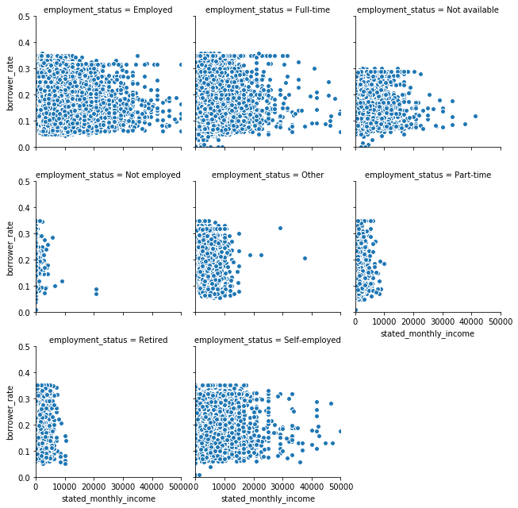

```python
# create multivariate faceted scatterplots
g = sb.FacetGrid(df, col='employment_status', col_wrap=3)
g.map(plt.scatter, 'stated_monthly_income', 'borrower_rate', edgecolor ='w')
plt.ylim(0, 0.5)
plt.xlim(0, 50000)
g.add_legend();
```

Borrowers whose employment status is either Employed, Full-time or Self-employed generally earn higher than other employment status groups.

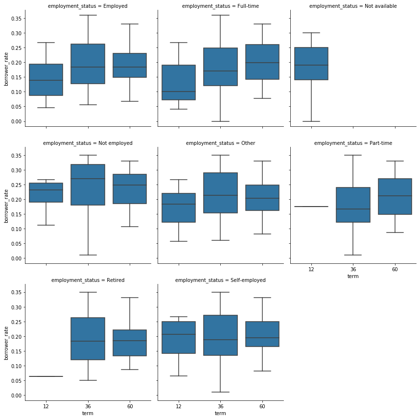

```python
# create faceted grids
g = sb.FacetGrid(df, col='employment_status', col_wrap = 3, height = 4)
g.map(sb.boxplot, 'term', 'borrower_rate')
```

Generally, those who are retired with a loan term of 12 months, have lower borrower_rates.

There seems to be a very slight positive relationship between borrower_rate & term for borrowers whose employment status is Full-time.

Onto to the final exploration

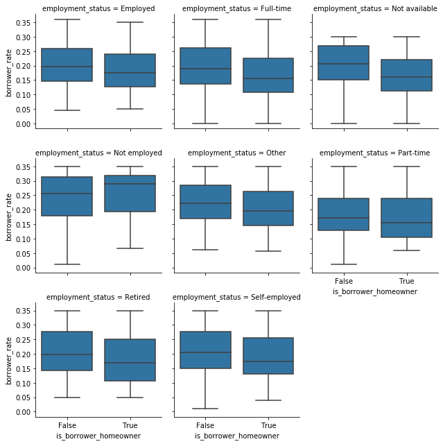

```python
# created faceted boxplots on levels of employment status
g = sb.FacetGrid(df, col='employment_status', col_wrap = 3, size = 3)
g.map(sb.boxplot, 'is_borrower_homeowner', 'borrower_rate');
```

For all employment status types besides those who are unemployed, the borrowers who own a home have a lesser borrower_rate that their counterparts who don't own a home.

### Talk about some of the relationships you observed in this part of the investigation. Were there features that strengthened each other in terms of looking at your feature(s) of interest?

I extended my investigation of borrower_rate against stated_monthly_income. This time I added a third variable (is_borrower_homeowner). The only notable insights acknowledged is the fact that some borrowers who don't own a home have higher interest rate than their counterparts that own a home

### Were there any interesting or surprising interactions between features?

While I sought to investigate further on the relationship between borrower_rate and stated_monthly_income, there was no solid interaction when juxtaposed with employment_status

Also, those who are retired and have a short term loan of 12 months had lower interest rates than other employment status types.

As for borrower_rate against is_borrower_homeowner, adding a third variable (employment_status) further consolidated the fact that borrowers who own a home have a lower borrower_rate than those who don't own a home.